# Ejercicio 2. Entrenamiento de modelos de clasificación con Keras

En este segundo ejercicio tendrás que trabajar con Keras para probar las técnicas que has visto hasta la Práctica 5.2, incluyendo regularización (L2, dropout, data augmentation, K-validación cruzada, etc.), capas convolucionales, pooling, densas, etc. con **al menos 4 configuraciones** distintas. Además, emplearás tu modelo con tu webcam.

Para ello, vas a tener que trabajar con un conjunto de datos sobre imágenes de personas que llevan o no máscara.

[figure not shown]

## 1. Enunciado

Empleando el dataset de mascarillas (ver apartado 3), debes construir y probar **al menos 4** configuraciones de modelos con Keras que sean sustancialmente distintas. Debes jugar con:

- K-validación y validación cruzada.
- Regularización: L1/L2, early stopping, dropout.
- Data augmentation: echando un vistazo al dataset, ¿qué tipo de transformación harías? ¿qué transformaciones NO harías? ¿qué ventaja se obtiene al usar aumentado?.
- Distintas arquitecturas de redes convolucionales: distinta cantidad y orden de capas convolucionales, pooling, densas, etc.
- Distintos optimizadores (Adam, RMSprop, momentum, etc.), factor de aprendizaje y número de épocas.
- Inicialización aleatoria de pesos (Normal, Xavier, Glorot, He).

Detalla cada configuración (arquitectura de red, hiperparámetros, etc), explicando brevemente cada componente empleada (cuando se use por primera vez en este trabajo, por ejemplo, cuando se use regularización L2, hay que explicar brevemente qué es), y haciendo uso de imágenes y figuras para representar la arquitectura de la red.

Después, entrénalas con los datos leídos y analiza los resultados, haciendo una comparativa y razonando lo obtenido.

## 2. Entrega

La entrega de este ejercicio se realiza a través de la tarea creada para tal efecto en Enseñanza Virtual. Tienes que entregar un notebook, y el HTML generado a partir de él, cuyas celdas estén ya evaluadas.

La estructura del notebook debe contener los siguientes apartados:

1. Cabecera: nombre y apellidos.
2. Dataset: descripción, carga y visualización.
3. Preparación de los datos para ser usados en Keras.
4. Modelos y configuraciones creados en Keras (un sub-apartado para cada uno, explicando de forma razonada, con tus palabras y figuras, la arquitectura probada).
5. Entrenamiento y evaluación de cada modelo creado (un sub-apartado para cada uno).
6. Análisis de resultados.
7. Bibliografía utilizada (enlaces web, material de clase, libros, etc.).

### 2.1. Nota importante

**HONESTIDAD ACADÉMICA Y COPIAS: un trabajo práctico es un examen, por lo que debe realizarse de manera individual. La discusión y el intercambio de información de carácter general con los compañeros se permite (e incluso se recomienda), pero NO AL NIVEL DE CÓDIGO. Igualmente el remitir código de terceros, OBTENIDO A TRAVÉS DE LA RED o cualquier otro medio, se considerará plagio.**

**Cualquier plagio o compartición de código que se detecte significará automáticamente la calificación de CERO EN LA ASIGNATURA para TODOS los alumnos involucrados. Por tanto a estos alumnos NO se les conservará, para futuras convocatorias, ninguna nota que hubiesen obtenido hasta el momento. SIN PERJUICIO DE OTRAS MEDIDAS DE CARÁCTER DISCIPLINARIO QUE SE PUDIERAN TOMAR.**

## 3. El Dataset: Mask Dataset

Este pequeño dataset está disponible en Kaggle. Es una versión reducida del construido en [este tutorial](https://www.pyimagesearch.com/2020/05/04/covid-19-face-mask-detector-with-opencv-keras-tensorflow-and-deep-learning/). La pandemia originada por el SARS-Cov2 ha propiciado la creación de diversos datasets para detectar si las personas están llevando mascarilla o no. En este dataset para este ejeercicio, tenemos imágenes de personas con y sin mascarilla (algunas se les ha puesto la mascarilla de forma "artificial"). El enlace al dataset es el siguiente [Face Mask Detection](https://www.kaggle.com/omkargurav/face-mask-dataset). Si no tienes cuenta en Kaggle, o si quieres ir más rápido, puedes ejecutar la siguiente celda. Descargará el dataset directamente en tu sesión/ordenador desde un enlace directo.

```python
from tensorflow import keras
import pathlib

# Esta función de Keras descargará el dataset en $HOME/.keras
data_path = keras.utils.get_file(
    "mask_dataset.zip",
    "https://hdvirtual.us.es/discovirt/index.php/s/dijNRMPYfybYd3N/download",
    extract=True,
    archive_format='zip'
)

# La siguiente variable contiene la ruta al dataset. Puedes evaluarla
# y después hacer !ls para ver el contenido
DATA_FOLDER = pathlib.Path(data_path).parent / 'mask_ds'
%ls $DATA_FOLDER

# Puedes usar el siguiente tamaño de imagen
IMAGE_SIZE = (128, 128)
```

En juyter tengo que cambiar !ls por %ls

# 4. Despliegue del modelo pre-entrenado

Una vez hayas entrenado un modelo (por ejemplo, `model`), puedes lanzar una de las siguientes celdas para hacer la prueba con tu WebCam. No es necesario que adjuntes capturas tuyas, pero sí que se valorará que hagas varias pruebas y analices el ratio de aciertos de tu modelo.

## 4.1 Capturando la WebCam desde Google Colab

Lanza las siguientes dos celdas para capturar una foto con tu web cam, si estás en Google Colab. Haz clic en el botón "Capture" (guardará la imagen en `image.jpg`).

```python
from IPython.display import display, Javascript
from google.colab.output import eval_js
from base64 import b64decode

def take_photo(filename='image.jpg', quality=0.8):
  js = Javascript('''
    async function takePhoto(quality) {
      const div = document.createElement('div');
      const capture = document.createElement('button');
      capture.textContent = 'Capture';
      div.appendChild(capture);

      const video = document.createElement('video');
      video.style.display = 'block';
      const stream = await navigator.mediaDevices.getUserMedia({video: true});

      document.body.appendChild(div);
      div.appendChild(video);
      video.srcObject = stream;
      await video.play();

      // Resize the output to fit the video element.
      google.colab.output.setIframeHeight(document.documentElement.scrollHeight, true);

      // Wait for Capture to be clicked.
      await new Promise((resolve) => capture.onclick = resolve);

      const canvas = document.createElement('canvas');
      canvas.width = video.videoWidth;
      canvas.height = video.videoHeight;
      canvas.getContext('2d').drawImage(video, 0, 0);
      stream.getVideoTracks()[0].stop();
      div.remove();
      return canvas.toDataURL('image/jpeg', quality);
    }
    ''')
  display(js)
  data = eval_js('takePhoto({})'.format(quality))
  binary = b64decode(data.split(',')[1])
  with open(filename, 'wb') as f:
    f.write(binary)
  return filename
```

```python
from IPython.display import Image
try:
  filename = take_photo()
  print('Saved to {}'.format(filename))

  # Show the image which was just taken.
  display(Image(filename))
except Exception as err:
  # Errors will be thrown if the user does not have a webcam or if they do not
  # grant the page permission to access it.
  print(str(err))
```

## 4.2 Capturando la WebCam desde local

El siguiente código debería permitirte capturar una foto desde tu webcam si estás en local.

```python
from IPython.display import HTML, display, update_display

main_text = """
<video id="video" width="320" height="240" autoplay style="display:none"></video>
<canvas id="canvas" width="320" height="240"  ></canvas>

<script>
// Grab elements, create settings, etc.
var video = document.getElementById('video');

// Get access to the camera!
if(navigator.mediaDevices && navigator.mediaDevices.getUserMedia) {
    // Not adding `{ audio: true }` since we only want video now
    navigator.mediaDevices.getUserMedia({ video: true }).then(function(stream) {
        //video.src = window.URL.createObjectURL(stream);
        //video.play();
        video.srcObject=stream;
        video.play();
    });
}

// Elements for taking the snapshot
var canvas = document.getElementById('canvas');
var context = canvas.getContext('2d');
var video = document.getElementById('video');


// Trigger photo take

setInterval(function() {
    context.drawImage(video, 0, 0, 320, 240);
    var myCanvas = document.getElementById('canvas');
    var image = myCanvas.toDataURL("image/png");
    IPython.notebook.kernel.execute("image = '" + image + "'")

}, 2);

</script>

"""
HTML(main_text)
```

# 4.3 Evaluando el modelo

La siguiente celda debería permitirte cargar un modelo guardado en la variable `model`, y usarlo para hacer predicción con la imagen capturada.

```python
from PIL import Image
import base64
from numpy import asarray
import io
import numpy as np
import time

#pil_im = Image.open(io.BytesIO(base64.b64decode(image.split(',')[1]))) # versión en local
pil_im = Image.open(filename)  # versión en google colab
pil_im = pil_im.convert('RGB')
pil_im = pil_im.resize(IMAGE_SIZE, Image.ANTIALIAS)
pil_im
```

```python
im = np.asarray(pil_im) / 255
print(model.predict(np.array([im])).argmax())  # Muestra la salida del modelo y el resultado (con o sin mascarilla)
result = 'con mascarilla' if model.predict(np.array([im])).argmax() == 0 else 'sin mascarilla'
print(result)
```

# Descripción

Para este segundo ejercicio vamos a trabajar con un conjunto de imágenes a color de personas con y sin máscaras, lo que queremos conseguir aquí es entrenar una red que consiga diferenciar a las personas que llevan mascarillas de las que no, para tener mayor cantidad de elementos se han aplicado algunas transformaciones a imágenes del conjunto de entrenamiento(rotaciones, espejo,difuminado).

En resumen, dispondremos de dos conjuntos: Entrenamiento y validación y en cada uno de ellos dispondremos de dos carpetas, con o sin mascarilla

# Carga

Para cargar los datos tendremos que descargarnos el conjunto que constará de dos carpetas, una de entrenamiento y otra de validación en la que dispondremos de unos 5000 elementos para entrenamiento y unos 2000 para validación, en ambos conjuntos tendremos imágenes de personas con y sin máscara a las que a algunas se les ha aplicado transformaciones para aumentar el dataset(en el entrenamiento solo)

```python
from tensorflow import keras
import pathlib

# Esta función de Keras descargará el dataset en $HOME/.keras
data_path = keras.utils.get_file(
    "mask_dataset.zip",
    "https://hdvirtual.us.es/discovirt/index.php/s/dijNRMPYfybYd3N/download",
    extract=True,
    archive_format='zip'
)

# La siguiente variable contiene la ruta al dataset. Puedes evaluarla
# y después hacer !ls para ver el contenido
DATA_FOLDER = pathlib.Path(data_path).parent / 'mask_ds'
%ls $DATA_FOLDER

# Puedes usar el siguiente tamaño de imagen
IMAGE_SIZE = (128, 128)
```

```
 El volumen de la unidad C no tiene etiqueta.
 El número de serie del volumen es: 7251-90EE

 Directorio de C:\Users\alarc\.keras\datasets\mask_ds

02/12/2023  18:08    <DIR>          .
03/12/2023  18:27    <DIR>          ..
02/12/2023  18:08    <DIR>          train
02/12/2023  18:08    <DIR>          validation
               0 archivos              0 bytes
               4 dirs  877.588.590.592 bytes libres
```

# Visualización

Aquí voy a cargar y mostrar una imagen de cada tipo(con y sin mascarilla) y las mostraré, podemos ver que las imágenes tienen distinto tamaño y existen de color y blanco y negro.

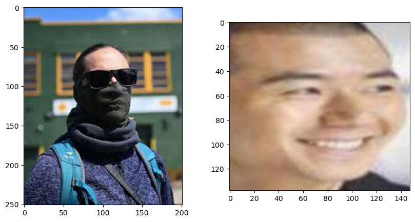

```python
from PIL import Image
import os
import matplotlib.pyplot as plt

# Directorio de entrenamiento donde vamos a buscar las imágenes
train_folder = DATA_FOLDER / 'train'


with_mask_folder = 'C:/Users/alarc/Desktop/Deep/Entrega 2/mask_ds/train/with_mask'

without_mask_folder = 'C:/Users/alarc/Desktop/Deep/Entrega 2/mask_ds/train/without_mask'

# Cargamos y mostramos las 2 imágenes
fig, axes = plt.subplots(1, 2, figsize=(10, 5))

# Con máscara
specific_image_with_mask = Image.open('C:/Users/alarc/Desktop/Deep/Entrega 2/mask_ds/train/with_mask/with_mask_2.jpg')
axes[0].imshow(specific_image_with_mask)

# Sin máscara
specific_image_without_mask = Image.open('C:/Users/alarc/Desktop/Deep/Entrega 2/mask_ds/train/without_mask/without_mask_2.jpg')
axes[1].imshow(specific_image_without_mask)

plt.show()
```

# Preparación de los datos

Como ya hemos visto anteriormente, el tratamiento de los datos es muy importante para las redes convolucionales. para empezar no tenemos un valor de clasificación real (las carpetas)

```python
base_dir = 'C:/Users/alarc/Desktop/Deep/Entrega 2/mask_ds/train'
base_dir_val = 'C:/Users/alarc/Desktop/Deep/Entrega 2/mask_ds/validation'

with_mask_dir = os.path.join(base_dir, 'with_mask')
without_mask_dir = os.path.join(base_dir, 'without_mask')

with_mask_dir_val = os.path.join(base_dir_val, 'with_mask')
without_mask_dir_val = os.path.join(base_dir_val, 'without_mask')

# Número de imágenes en 'with_mask'
print('Número de imágenes de entrenamiento con mascara:', len(os.listdir(with_mask_dir)))
# Número de imágenes en 'without_mask'
print('Número de imágenes de entrenamiento sin mascara:', len(os.listdir(without_mask_dir)))
# Total
print('Total de imágenes de entrenamiento:', len(os.listdir(with_mask_dir)) + len(os.listdir(with_mask_dir)))

print()

# Número de imágenes en 'with_mask'
print('Número de imágenes de validación con mascara:', len(os.listdir(with_mask_dir_val)))
# Número de imágenes en 'without_mask'
print('Número de imágenes de validación sin mascara:', len(os.listdir(without_mask_dir_val)))
#Total
print('Total de imágenes de validación:', len(os.listdir(with_mask_dir_val)) + len(os.listdir(with_mask_dir_val)))
```

```
Número de imágenes de entrenamiento con mascara: 2759
Número de imágenes de entrenamiento sin mascara: 2822
Total de imágenes de entrenamiento: 5518

Número de imágenes de validación con mascara: 1118
Número de imágenes de validación sin mascara: 1149
Total de imágenes de validación: 2236
```

El problema que tenemos ahora es que lo que disponemos son imágenes JPG, por lo que tendremos recodificar la imagen a una matriz RGB ,es decir, tenemos que convertir las imagenes en matrices para poder procesarlas

```python
from keras.preprocessing.image import ImageDataGenerator

# Todas las imágenes serán re-escaladas por 1,0/255
train_datagen = ImageDataGenerator(rescale=1./255)
test_datagen = ImageDataGenerator(rescale=1./255)

train_generator = train_datagen.flow_from_directory(
        # Este es el directorio destino
        base_dir,
        # Todas las imágenes serán redimensionadas a 150x150
        target_size=(150, 150),
        batch_size=50,
        # Puesto que usamos la pérdida binary_crossentropy, necesitamos etiquetas binarias
        class_mode='binary')

validation_generator = test_datagen.flow_from_directory(
        base_dir_val,
        target_size=(150, 150),
        batch_size=20,
        class_mode='binary')
```

```
Found 5581 images belonging to 2 classes.
Found 2267 images belonging to 2 classes.
```

Vamos a ver como nos quedan las imágenes de un batch tras la transformación

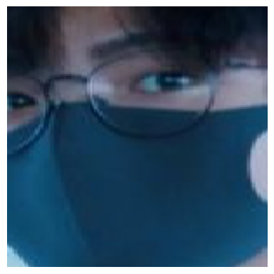

```python
import matplotlib.pyplot as plt

# lote de imágenes del generador de entrenamiento
batch = next(train_generator)

#primera imagen del lote
image = batch[0][0]

# Visualiza la imagen
plt.imshow(image)
plt.axis('off')
plt.show()
```

# Modelos y configuraciones creados en Keras

## Modelo 1

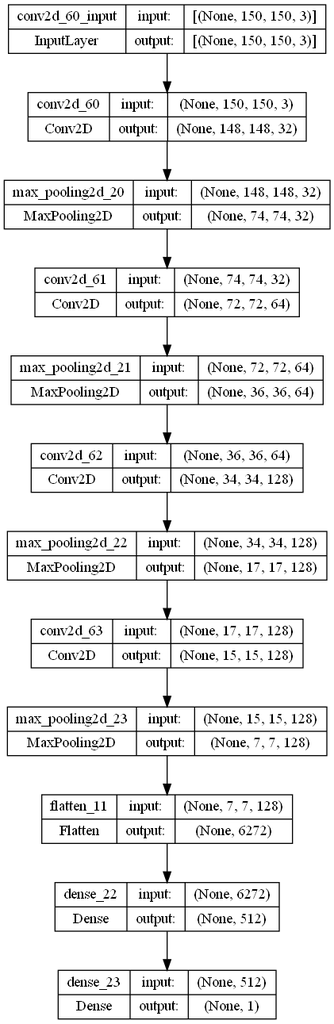

```python
from keras import layers
from keras import models
#from keras.utils.vis_utils import plot_model
from keras.utils import plot_model
from keras import regularizers


CNN1 = models.Sequential()
CNN1.add(layers.Conv2D(32, (3, 3),kernel_regularizer=regularizers.l2(0.001) ,activation='relu',
                        input_shape=(150, 150, 3)))
CNN1.add(layers.MaxPooling2D((2, 2)))
CNN1.add(layers.Conv2D(64, (3, 3), kernel_regularizer=regularizers.l2(0.001),activation='relu'))
CNN1.add(layers.MaxPooling2D((2, 2)))
CNN1.add(layers.Conv2D(128, (3, 3),kernel_regularizer=regularizers.l2(0.001), activation='relu'))
CNN1.add(layers.MaxPooling2D((2, 2)))
CNN1.add(layers.Conv2D(128, (3, 3),kernel_regularizer=regularizers.l2(0.001), activation='relu'))
CNN1.add(layers.MaxPooling2D((2, 2)))
CNN1.add(layers.Flatten())
CNN1.add(layers.Dense(512, activation='relu'))
CNN1.add(layers.Dense(1, activation='sigmoid'))

plot_model(CNN1, to_file='CNN1_plot.png', show_shapes=True, show_layer_names=True)
```

```python
from keras import optimizers

CNN1.compile(loss='binary_crossentropy',
              optimizer=optimizers.RMSprop(learning_rate=1e-4),
              metrics=['acc'])
```

## Modelo 2

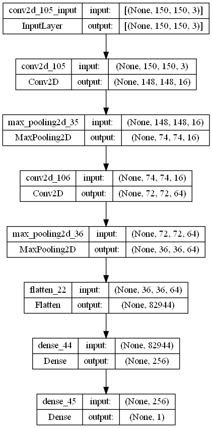

```python
from keras import layers
from keras import models
#from keras.utils.vis_utils import plot_model
from keras.utils import plot_model
from keras import regularizers


CNN2 = models.Sequential()
CNN2.add(layers.Conv2D(16, (3, 3),kernel_regularizer=regularizers.l1(0.002) ,activation='relu',
                        input_shape=(150, 150, 3)))
CNN2.add(layers.MaxPooling2D((2, 2)))
CNN2.add(layers.Conv2D(64, (3, 3), kernel_regularizer=regularizers.l1(0.002),activation='relu'))
CNN2.add(layers.MaxPooling2D((2, 2)))
CNN2.add(layers.Flatten())
CNN2.add(layers.Dense(256, activation='relu'))
CNN2.add(layers.Dense(1, activation='sigmoid'))

plot_model(CNN2, to_file='CNN2_plot.png', show_shapes=True, show_layer_names=True)
```

```python
from keras import optimizers

CNN2.compile(loss='binary_crossentropy',
              optimizer=optimizers.Adam(learning_rate=0.01),
              metrics=['acc'])
```

## Modelo 3

Lo que he aplicado en eeste modelo ha sido:

- Regularización:
  - L2=0.001:
  - Early stopping=2
  - Dropout=0.5
- Arquitecturas de redes convolucionales:
  - LeakyReLU : Similar a la relu pero esta permite una pequeña pendiente para los valores negativos mientras que en relu los negativos eran 0
  - Sigmoid de salida ya que estamos en un problema de clasificación binaria(tiene o no mascarilla)
  - MaxPooling2D
- Optimizadores
  - SGD: El desdenso por gradiente busca minimizar la fnución de perdida actualizando los pesos, en cada iteración, calculamos el gradiente de la función de pérdida con respecto a los pesos y actualiza los pesos en la dirección opuesta al gradiente
  - Factor de aprendizaje: 0.01, Momentum=0.9 l momentum es un hiperparámetro que suaviza la trayectoria del algoritmo
  - Nº de epocas: 20
- Inicialización aleatoria de pesos
  - Pesos aleatorios

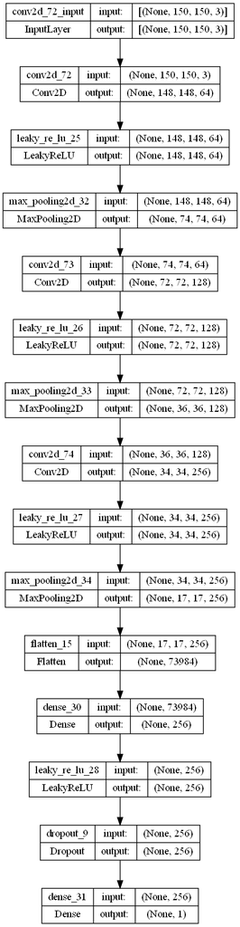

```python
from keras import layers
from keras import models
from keras.utils import plot_model
from keras import regularizers

CNN3 = models.Sequential()
CNN3.add(layers.Conv2D(64, (3, 3), kernel_regularizer=regularizers.l2(0.001), input_shape=(150, 150, 3)))
CNN3.add(layers.LeakyReLU(alpha=0.01))
CNN3.add(layers.MaxPooling2D((2, 2)))
CNN3.add(layers.Conv2D(128, (3, 3), kernel_regularizer=regularizers.l2(0.001)))
CNN3.add(layers.LeakyReLU(alpha=0.01))
CNN3.add(layers.MaxPooling2D((2, 2)))
CNN3.add(layers.Conv2D(256, (3, 3), kernel_regularizer=regularizers.l2(0.001)))
CNN3.add(layers.LeakyReLU(alpha=0.01))
CNN3.add(layers.MaxPooling2D((2, 2)))

CNN3.add(layers.Flatten())
CNN3.add(layers.Dense(256, kernel_regularizer=regularizers.l2(0.001)))
CNN3.add(layers.LeakyReLU(alpha=0.01))
CNN3.add(layers.Dropout(0.5))
CNN3.add(layers.Dense(1, activation='sigmoid'))

plot_model(CNN3, to_file='CNN3.png', show_shapes=True, show_layer_names=True)
```

```python
from keras import optimizers

CNN3.compile(loss='binary_crossentropy', optimizer=optimizers.SGD(learning_rate=0.01, momentum=0.9), metrics=['acc'])
```

## Modelo 4

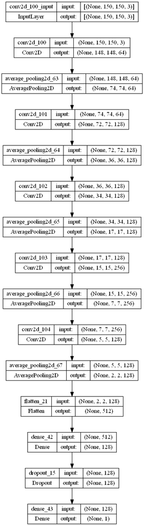

```python
from keras import layers
from keras import models
from keras.utils import plot_model
from keras import regularizers
from keras.initializers import he_normal

CNN4 = models.Sequential()

CNN4.add(layers.Conv2D(64, (3, 3), kernel_initializer=he_normal(), kernel_regularizer=regularizers.l2(0.005), input_shape=(150, 150, 3)))
CNN4.add(layers.AveragePooling2D((2, 2)))

CNN4.add(layers.Conv2D(128, (3, 3), kernel_initializer=he_normal(), kernel_regularizer=regularizers.l2(0.005)))
CNN4.add(layers.AveragePooling2D((2, 2)))

CNN4.add(layers.Conv2D(128, (3, 3), kernel_initializer=he_normal(), kernel_regularizer=regularizers.l2(0.005)))
CNN4.add(layers.AveragePooling2D((2, 2)))

CNN4.add(layers.Conv2D(256, (3, 3), kernel_initializer=he_normal(), kernel_regularizer=regularizers.l2(0.005)))
CNN4.add(layers.AveragePooling2D((2, 2)))

CNN4.add(layers.Conv2D(128, (3, 3), kernel_initializer=he_normal(), kernel_regularizer=regularizers.l2(0.005)))
CNN4.add(layers.AveragePooling2D((2, 2)))


CNN4.add(layers.Flatten())
CNN4.add(layers.Dense(128, kernel_initializer=he_normal(), kernel_regularizer=regularizers.l2(0.005)))
CNN4.add(layers.Dropout(0.7))

CNN4.add(layers.Dense(1, activation='sigmoid'))

plot_model(CNN4, to_file='CNN4.png', show_shapes=True, show_layer_names=True)
```

```python
from keras import optimizers
CNN4.compile(loss='binary_crossentropy', optimizer=optimizers.AdamW(learning_rate=0.003), metrics=['acc'])
```

# Entrenamiento y evaluación de cada modelo creado

## Modelo 1

```python
entrenamiento1 = CNN1.fit(
      train_generator,
      steps_per_epoch=100,
      epochs=10,
      validation_data=validation_generator,
      validation_steps=50)
```

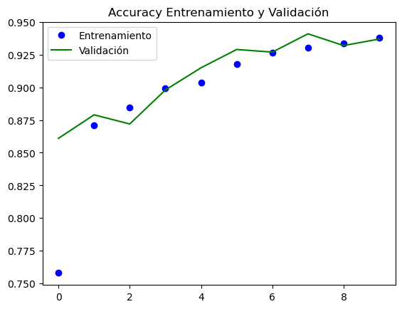

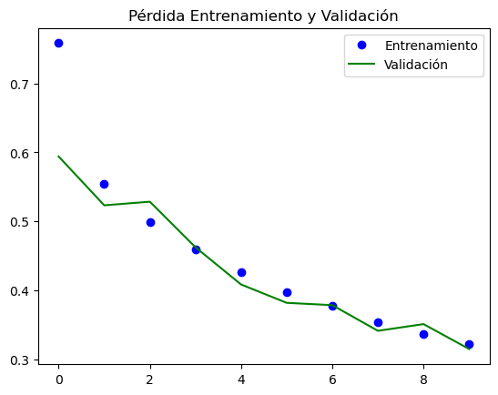

```python
import matplotlib
%matplotlib inline
import matplotlib.pyplot as plt

ent_acc = entrenamiento1.history['acc']
val_acc = entrenamiento1.history['val_acc']
ent_loss = entrenamiento1.history['loss']
val_loss = entrenamiento1.history['val_loss']

epochs = range(len(ent_acc))

plt.plot(epochs, ent_acc, 'bo', label='Entrenamiento')
plt.plot(epochs, val_acc, 'g', label='Validación')
plt.title('Accuracy Entrenamiento y Validación')
plt.legend()

plt.figure()

plt.plot(epochs, ent_loss, 'bo', label='Entrenamiento')
plt.plot(epochs, val_loss, 'g', label='Validación')
plt.title('Pérdida Entrenamiento y Validación')
plt.legend()

plt.show()
```

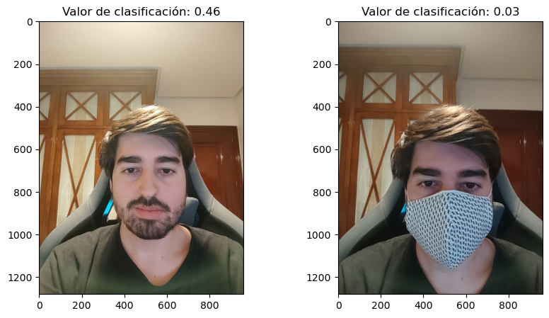

```python
from keras.preprocessing import image
import numpy as np
import matplotlib.pyplot as plt

# Rutas de las imágenes
image_path1 = 'C:/Users/alarc/Desktop/Deep/Entrega 2/mask_ds/mias/sinMascara.jpg'
image_path2 = 'C:/Users/alarc/Desktop/Deep/Entrega 2/mask_ds/mias/conMascara.jpg'

# Función para cargar y preprocesar la imagen
def preprocess_image(image_path):
    img = image.load_img(image_path, target_size=(150, 150))
    img_array = image.img_to_array(img)
    img_array = np.expand_dims(img_array, axis=0)
    img_array /= 255.0
    return img_array


# Preprocesar las imágenes
img_array1 = preprocess_image(image_path1)
img_array2 = preprocess_image(image_path2)

# Realizar las predicciones
prediction1 = CNN1.predict(img_array1)
prediction2 = CNN1.predict(img_array2)

# Mostrar las imágenes junto con las predicciones
plt.figure(figsize=(10, 5))

# Primera imagen
plt.subplot(1, 2, 1)
plt.imshow(image.load_img(image_path1))
plt.title(f'Valor de clasificación: {prediction1[0][0]:.2f}')

# Segunda imagen
plt.subplot(1, 2, 2)
plt.imshow(image.load_img(image_path2))
plt.title(f'Valor de clasificación: {prediction2[0][0]:.2f}')

plt.show()
```

## Modelo 2

```python
from keras.callbacks import EarlyStopping

early_stopping2 = EarlyStopping(monitor='val_loss', patience=5)


entrenamiento2 = CNN2.fit(
      train_generator,
      steps_per_epoch=75,
      epochs=15,
      validation_data=validation_generator,
      callbacks=[early_stopping2],
      validation_steps=75)
```

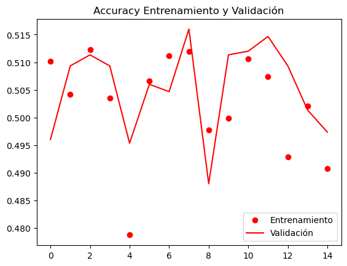

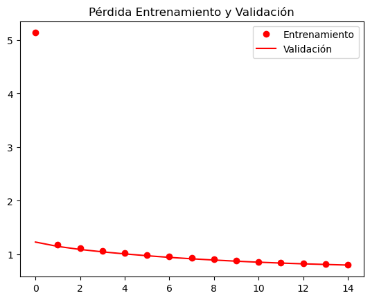

```python
import matplotlib
%matplotlib inline
import matplotlib.pyplot as plt

ent_acc = entrenamiento2.history['acc']
val_acc = entrenamiento2.history['val_acc']
ent_loss = entrenamiento2.history['loss']
val_loss = entrenamiento2.history['val_loss']

epochs = range(len(ent_acc))

plt.plot(epochs, ent_acc, 'ro', label='Entrenamiento')
plt.plot(epochs, val_acc, 'r', label='Validación')
plt.title('Accuracy Entrenamiento y Validación')
plt.legend()

plt.figure()

plt.plot(epochs, ent_loss, 'ro', label='Entrenamiento')
plt.plot(epochs, val_loss, 'r', label='Validación')
plt.title('Pérdida Entrenamiento y Validación')
plt.legend()

plt.show()
```

[output not shown]

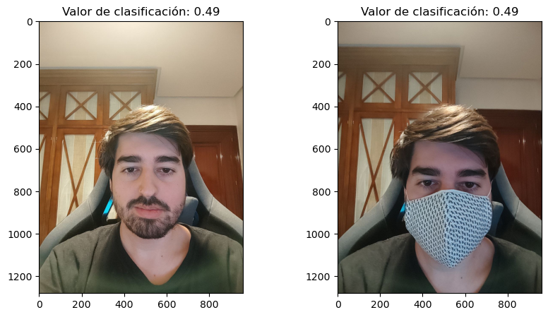

```python
# Realizar las predicciones
prediction1 = CNN2.predict(img_array1)
prediction2 = CNN2.predict(img_array2)

# Mostrar las imágenes junto con las predicciones
plt.figure(figsize=(10, 5))

# Primera imagen
plt.subplot(1, 2, 1)
plt.imshow(image.load_img(image_path1))
plt.title(f'Valor de clasificación: {prediction1[0][0]:.2f}')

# Segunda imagen
plt.subplot(1, 2, 2)
plt.imshow(image.load_img(image_path2))
plt.title(f'Valor de clasificación: {prediction2[0][0]:.2f}')

plt.show()
```

## Modelo 3

```python
from keras.callbacks import EarlyStopping

early_stopping3 = EarlyStopping(monitor='val_acc', patience=2)

from keras import optimizers

CNN3.compile(loss='binary_crossentropy', optimizer=optimizers.SGD(learning_rate=0.01, momentum=0.9), metrics=['acc'])

entrenamiento3 = CNN3.fit(
      train_generator,
      steps_per_epoch=100,
      epochs=20,
      validation_data=validation_generator,
      callbacks=[early_stopping3],
      validation_steps=60)
```

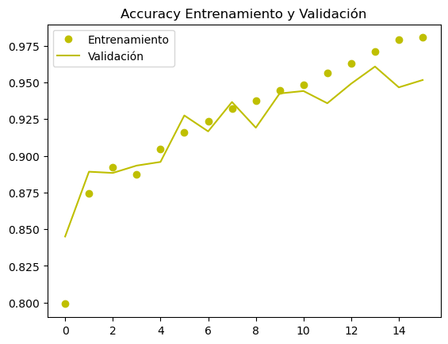

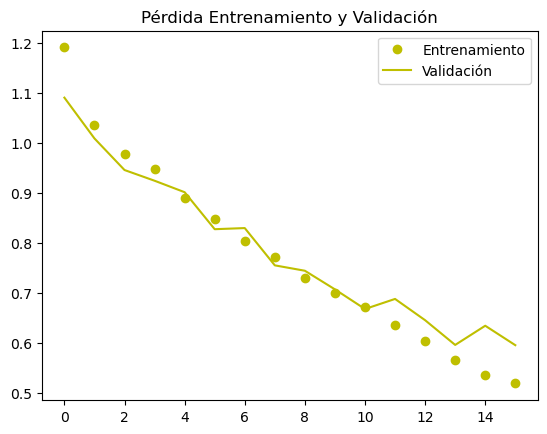

```python
import matplotlib
%matplotlib inline
import matplotlib.pyplot as plt

ent_acc = entrenamiento3.history['acc']
val_acc = entrenamiento3.history['val_acc']
ent_loss = entrenamiento3.history['loss']
val_loss = entrenamiento3.history['val_loss']

epochs = range(len(ent_acc))

plt.plot(epochs, ent_acc, 'yo', label='Entrenamiento')
plt.plot(epochs, val_acc, 'y', label='Validación')
plt.title('Accuracy Entrenamiento y Validación')
plt.legend()

plt.figure()

plt.plot(epochs, ent_loss, 'yo', label='Entrenamiento')
plt.plot(epochs, val_loss, 'y', label='Validación')
plt.title('Pérdida Entrenamiento y Validación')
plt.legend()

plt.show()
```

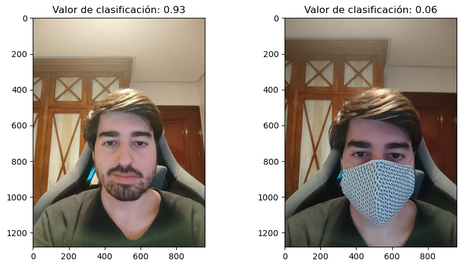

```python
from keras.preprocessing import image
import numpy as np
import matplotlib.pyplot as plt

# Rutas de las imágenes
image_path1 = 'C:/Users/alarc/Desktop/Deep/Entrega 2/mask_ds/mias/sinMascara.jpg'
image_path2 = 'C:/Users/alarc/Desktop/Deep/Entrega 2/mask_ds/mias/conMascara.jpg'

# Función para cargar y preprocesar la imagen
def preprocess_image(image_path):
    img = image.load_img(image_path, target_size=(150, 150))
    img_array = image.img_to_array(img)
    img_array = np.expand_dims(img_array, axis=0)
    img_array /= 255.0
    return img_array

# Preprocesar las imágenes
img_array1 = preprocess_image(image_path1)
img_array2 = preprocess_image(image_path2)

# Realizar las predicciones
prediction1 = CNN3.predict(img_array1)
prediction2 = CNN3.predict(img_array2)

# Mostrar las imágenes junto con las predicciones
plt.figure(figsize=(10, 5))

# Primera imagen
plt.subplot(1, 2, 1)
plt.imshow(image.load_img(image_path1))
plt.title(f'Valor de clasificación: {prediction1[0][0]:.2f}')

# Segunda imagen
plt.subplot(1, 2, 2)
plt.imshow(image.load_img(image_path2))
plt.title(f'Valor de clasificación: {prediction2[0][0]:.2f}')

plt.show()
```

## Modelo 4

```python
early_stopping4 = EarlyStopping(monitor='acc', patience=6)


entrenamiento4 = CNN4.fit(
      train_generator,
      steps_per_epoch=50,
      epochs=10,
      validation_data=validation_generator,
      callbacks=[early_stopping4],
      validation_steps=60)
```

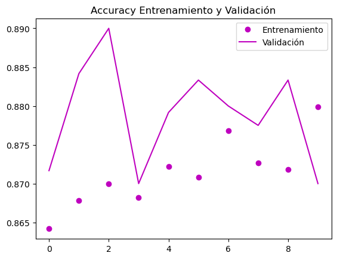

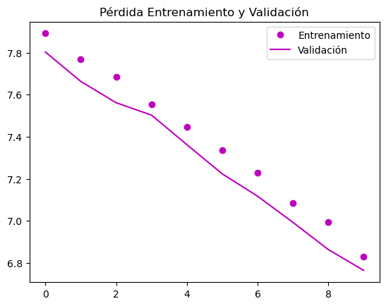

```python
import matplotlib
%matplotlib inline
import matplotlib.pyplot as plt

ent_acc = entrenamiento4.history['acc']
val_acc = entrenamiento4.history['val_acc']
ent_loss = entrenamiento4.history['loss']
val_loss = entrenamiento4.history['val_loss']

epochs = range(len(ent_acc))

plt.plot(epochs, ent_acc, 'mo', label='Entrenamiento')
plt.plot(epochs, val_acc, 'm', label='Validación')
plt.title('Accuracy Entrenamiento y Validación')
plt.legend()

plt.figure()

plt.plot(epochs, ent_loss, 'mo', label='Entrenamiento')
plt.plot(epochs, val_loss, 'm', label='Validación')
plt.title('Pérdida Entrenamiento y Validación')
plt.legend()

plt.show()
```

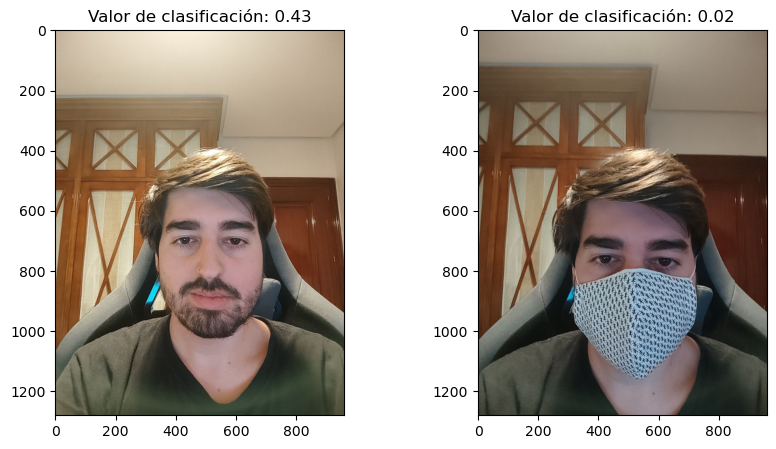

```python
from keras.preprocessing import image
import numpy as np
import matplotlib.pyplot as plt

# Rutas de las imágenes
image_path1 = 'C:/Users/alarc/Desktop/Deep/Entrega 2/mask_ds/mias/sinMascara.jpg'
image_path2 = 'C:/Users/alarc/Desktop/Deep/Entrega 2/mask_ds/mias/conMascara.jpg'

# Función para cargar y preprocesar la imagen
def preprocess_image(image_path):
    img = image.load_img(image_path, target_size=(150, 150))
    img_array = image.img_to_array(img)
    img_array = np.expand_dims(img_array, axis=0)
    img_array /= 255.0
    return img_array

# Preprocesar las imágenes
img_array1 = preprocess_image(image_path1)
img_array2 = preprocess_image(image_path2)

# Realizar las predicciones
prediction1 = CNN4.predict(img_array1)
prediction2 = CNN4.predict(img_array2)

# Mostrar las imágenes junto con las predicciones
plt.figure(figsize=(10, 5))

# Primera imagen
plt.subplot(1, 2, 1)
plt.imshow(image.load_img(image_path1))
plt.title(f'Valor de clasificación: {prediction1[0][0]:.2f}')

# Segunda imagen
plt.subplot(1, 2, 2)
plt.imshow(image.load_img(image_path2))
plt.title(f'Valor de clasificación: {prediction2[0][0]:.2f}')

plt.show()
```

# Análisis de resultados.

Podemos ver en el modelo 1 que no hay sobreajuste en el conjunto de entrenamiento, se adapta muy bien el conjunto de validación(tiene un rendimiento practicamente igual o ligeramente superior que el de entrenamiento)

El segundo tiene un rendimiento algo malo (alrededor del 50%) y es igual en validación, para este modelo he reducido el nº de neuronas y capas en gran medida y quizás debido a esto el modelo no aprende patrones y por tanto resulta en un mal rendimiento

El tercer modelo tiene un buen rendimiento (superior al 93%) en ambos conjuntos y la perdida es cada vez menor y también similar, se puede observar en este modelo que a partir de la iteración 10 u la 11 se puede apreciar que empieza un sobreajuste,sería bueno detener el entrenamiento en esta iteración ya que el rendimiento en las anteriores es bueno.

El último modelo he aplicado da un rendimiento mejor en el conjunto de validación que en el de entrenamiento, creo que se debe a que no ha sabido clasificar bien las imagenes que he generado y eso ha afectado al rendimiento

En mis imágenes de prueba como se pide en el ejercicio se ve que el valor de clasificación de mis fotos da un valor parecido al rendimiento de los conjuntos (por ejemplo el segundo que no se adapta bien y se queda en un 50% de rendimiento le da a mi imagen con y sin mascarilla a ambas imagenes un 0.5). el tercer modelo es que el mejor diferencia las fotos dando un 0.93 a la clasificación de mi imagen

Algunas conclusiones de los resultados:

A la hora de elegir el tamaño de los epochs debemos tener en cuenta que:

- Un epoch pequeño, nos ayuda a converger mas rápido pues hacemos más actualizaciones de los pesos(con más frecuencia), por lo tanto usá menos memoria pero puede introducir ruido
- Un epoch más grande o de todo el conjunto en consecuencia tiene menos ruido y puede aprender modelos más "robustos" y generalizables, en consecuencia es más lento y tiene mayor coste computacional
- He probado varias funciones y la que mejor resultado me ha dado ha sido cuando he usado es la relu, aunque el rendimiento del 4 modelo con función de activación lineal me ha dado un buen resultado
- He aplicado capas de pooling de MAX y AVG y he obtenido mejor rendimiento con MAX, quizás porque esta enfatiza las caracteristicas relevantes mientras que la avg es mas suave y reduce las variaciones/sobreajuste

El early stopping es una gran herramienta para cuando queremos monitorizar el aprendizaje del modelo y detenerlo en caso de que el entrenamiento este deteriorando el modelo en la métrica que le hayamos dado para controlar

# Bibliografía utilizada

https://colab.research.google.com/github/miguelamda/DL/blob/master/5.%20Redes%20Convolucionales/Practica5.1.%20Introducci%C3%B3n%20CNN.ipynb#scrollTo=YIec-or9WPEy

https://colab.research.google.com/github/miguelamda/DL/blob/master/5.%20Redes%20Convolucionales/Practica5.2.%20CNN%20con%20datasets%20peque%C3%B1os.ipynb#scrollTo=CZNNITazYzk-

https://es.mathworks.com/discovery/convolutional-neural-network-matlab.html

https://keras.io/api/layers/activations/

https://www.diegocalvo.es/funcion-de-activacion-redes-neuronales/

# Extra - Generador de imágenes

Lo que hago en este metodo es seleccionar los directorios donde estan las imagenes y donde guardar las nuevas, le añado algunas transformaciones(rotaciones difuminado,zoom, modo espejo(le pongo del reves)) y pongo el método a iterar un segundo para generar unas 200 imágenes aproximadamente

- Esta basado en la práctica 5.2 donde veíamos como trabajar con datasets pequeños

```python
from keras.preprocessing import image
from keras.preprocessing.image import ImageDataGenerator
import os
import time

original_dir = 'C:/Users/alarc/Desktop/Deep/Entrega 2/mask_ds/train/without_mask'
augmented_dir = 'C:/Users/alarc/Desktop/Deep/Entrega 2/mask_ds/aumento/'

# Lista de nombres de archivos en el directorio original
fnames = [os.path.join(original_dir, fname) for fname in os.listdir(original_dir)]

# Configuración del generador de imágenes aumentadas
datagen = ImageDataGenerator(
    rotation_range=20,
    width_shift_range=0.1,
    height_shift_range=0.1,
    shear_range=0.1,
    zoom_range=0.1,
    horizontal_flip=True,
    fill_mode='nearest'
)

# Límite máximo de imágenes
total_augmented_images = 500
# Contador para rastrear el número total de imágenes creadas
created_images_count = 0
# Iterar durante 1 segundo
start_time = time.time()

# Itera sobre las imágenes originales y crea las aumentadas
for fname in fnames:
    img_path = fname

    # redimensioanmos la imagen
    img = image.load_img(img_path, target_size=(150, 150))
    x = image.img_to_array(img)
    x = x.reshape((1,) + x.shape)


    images_for_current_original = min(total_augmented_images, total_augmented_images // len(fnames))

    # Crea las imagenes y las guardo en el directorio
    for i, batch in enumerate(datagen.flow(x, batch_size=1, save_to_dir=augmented_dir,save_prefix=fname.split("/")[-1].split(".")[0], save_format='jpeg')):

        created_images_count += 1
        if i >= images_for_current_original - 1 or time.time() - start_time > 1:
            break

    if time.time() - start_time > 1:
        break

print("Terminado el generador")
```

```
Terminado el generador
```